# Auto Insurance Analysis

### *Categorical variables Visualization*

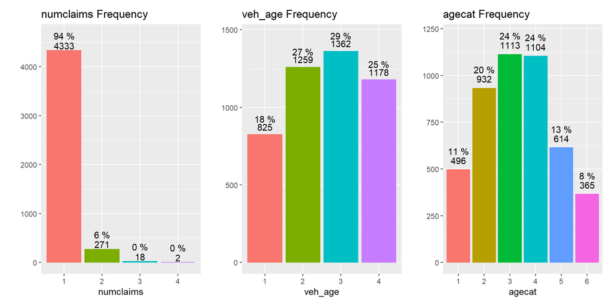

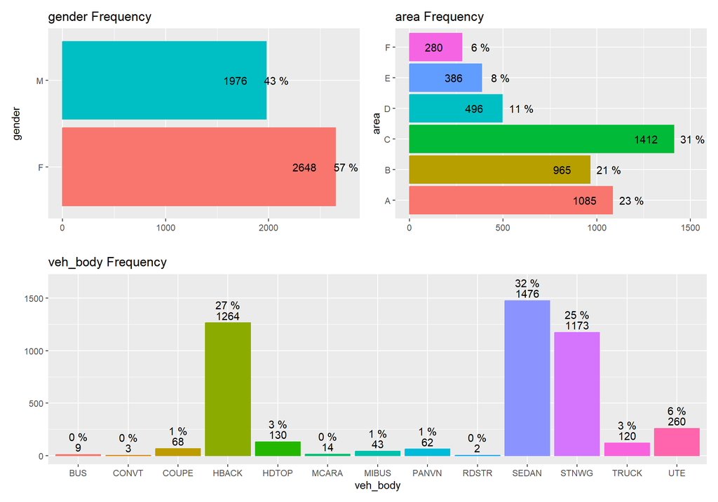

**————————————————————————**

# *Inferential Analysis*

## *choosing the Right statistics tests*

- *In Order To determine what types of statistical tests we will apply , we need to to determine Normality of the target variable (claims):*

### *claimcst0 variable Normality check by conducting Visualization*

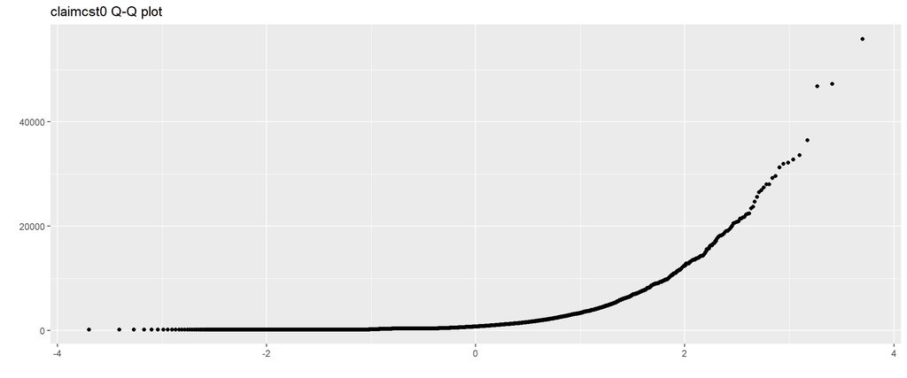

### *claims variable Normality check by Applying Anderson-Darling normality test*

```
##
##  Anderson-Darling normality test
##
## data:  df$claimcst0
## A = 654.01, p-value < 2.2e-16
```

*Based on our above analysis results:*

- *Normality: The Anderson-Darling normality test (p-value < 0.05) indicates non-normal distribution.*

*==> Given these results, We will be using non-parametric statistical tests*

## *Aplying non-parametric statistical tests*

### *A. Mann-Whitney U Test*

*Mann-Whitney U Test -for features that have 2 categories : equivelent to wilcox.test() wilcox rank sum test with continuity correction,better than wilcox sighned rank exct test(that used when variables are paired)*

- *A.1 Mann-Whitney U Test on claimcst0 against gender*

```
##
##  Wilcoxon rank sum test with continuity correction
##
## data:  df$claimcst0 by df$gender
## W = 2520284, p-value = 0.03234
## alternative hypothesis: true location shift is not equal to 0
```

*After Applying the test we found that:*

*The pvalue is less than 0.05 –> statistically there is significant difference in the data distribution between genders*

- *A.2 Visualization*

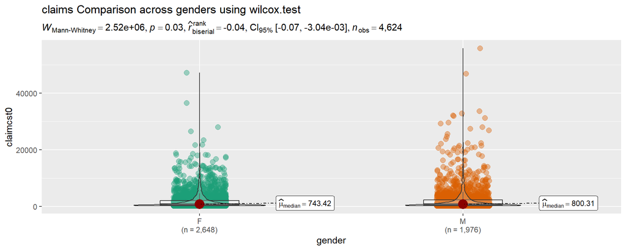

- *A.3 wilcox_effsize :*
- *now we want to assess and report the effect size and the magnitude of differences between these groups*

```
## # A tibble: 1 × 7
##   .y.       group1 group2 effsize    n1    n2 magnitude
## * <chr>     <chr>  <chr>    <dbl> <int> <int> <ord>
## 1 claimcst0 F      M       0.0315  2648  1976 small
```

*The wilcox_effsize test showed that the effect size= .0315 and the indicating small effect size*

- *A.4 Assumption Checks:*
- *Check the homogeneity of variances using Levene’s test.*

```r
levene_test <- leveneTest(claimcst0~gender,data = df)
print(levene_test)
```

```
## Levene's Test for Homogeneity of Variance (center = median)
##         Df F value    Pr(>F)
## group    1  12.543 0.0004016 ***
##       4622
## ---
## Signif. codes:  0 '***' 0.001 '**' 0.01 '*' 0.05 '.' 0.1 ' ' 1
```

- *The test indicates that the variances are significantly different across the groups (p-value < 0.05).*
- *A.5 Post-hoc Power Analysis:*
- *Conduct a post-hoc power analysis based on the effect size.*

```r
# Post-hoc Power Analysis
#t-test (two samples with unequal n)
library(pwr)
effect_size_value <- effect_size$effsize
power_analysis <- pwr.t2n.test(n1 = length(df$gender=="M"), n2 = length(df$gender=="F"),
                               d = effect_size_value,
                               sig.level = 0.05, power = NULL)
print(power_analysis)
```

```
##
##      t test power calculation
##
##              n1 = 4624
##              n2 = 4624
##               d = 0.03147296
##       sig.level = 0.05
##           power = 0.3277674
##     alternative = two.sided
```

- *The power of the test is 0.3277674,This means there is a 32.77% chance of detecting a true effect.*

### *B. kruskal.test*

#### *B.1 kruskal.test on claims against area*

- *B.1.1 kruskal.test on claims against area as it has more than 2 factors*

```
##
##  Kruskal-Wallis rank sum test
##
## data:  df$claimcst0 and df$area
## Kruskal-Wallis chi-squared = 26.616, df = 5, p-value = 6.776e-05
```

*After Applying the test we found that:*

*The pvalue is less than 0.05 –> statistically there is significant difference in the data distribution between areas*

- *B.1.2 Visualization*

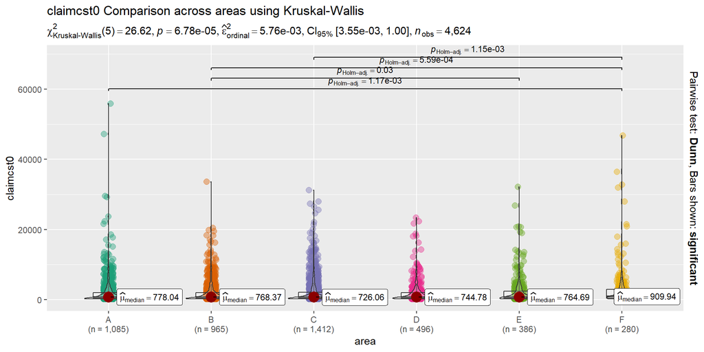

- *B.1.3 kruskal_effsize :*
- *now we want to assess and report the effect size and the magnitude of differences between these groups*

| .y. | n | effsize | method | magnitude |
| --- | --- | --- | --- | --- |
| claimcst0 | 4624 | 0.0046807 | eta2[H] | small |

- *The kruskal_effsize test showed that the effect size (epsilon_squared)= 0.004680724 and the indicating small effect size*
- *B.1.4 to find out in details these differences we will Perform Dunn’s Test with holm correction for p-values :*

```
##    Comparison          Z      P.unadj        P.adj
## 1       A - B  0.3929272 6.943733e-01 1.0000000000
## 2       A - C -0.1226836 9.023577e-01 0.9023576683
## 3       B - C -0.5348567 5.927489e-01 1.0000000000
## 4       A - D -1.0455938 2.957486e-01 1.0000000000
## 5       B - D -1.3404712 1.800922e-01 1.0000000000
## 6       C - D -0.9908884 3.217401e-01 1.0000000000
## 7       A - E -2.8037166 5.051729e-03 0.0505172881
## 8       B - E -3.0477582 2.305554e-03 0.0276666430
## 9       C - E -2.8067635 5.004197e-03 0.0550461713
## 10      D - E -1.6131418 1.067137e-01 0.8537095799
## 11      A - F -3.9167774 8.974053e-05 0.0011666269
## 12      B - F -4.1238931 3.725219e-05 0.0005587828
## 13      C - F -3.9375509 8.231746e-05 0.0011524445
## 14      D - F -2.7541273 5.884887e-03 0.0529639842
## 15      E - F -1.2278040 2.195206e-01 1.0000000000
```

*From the above table we can get that :*

- *The p.adjusted value is less than 0.05 between area B-E ,area A-F,area B-F,area C-F –> statistically there is significant difference in the data distribution between these groups,and there is no statistically significant difference in the data distribution between all other area groups*
- *B.1.5 Assumption Checks:*
- *Check the homogeneity of variances using Levene’s test.*

```r
levene_test <- leveneTest(claimcst0 ~area,data=df)
print(levene_test)
```

```
## Levene's Test for Homogeneity of Variance (center = median)
##         Df F value   Pr(>F)
## group    5  3.9598 0.001384 **
##       4618
## ---
## Signif. codes:  0 '***' 0.001 '**' 0.01 '*' 0.05 '.' 0.1 ' ' 1
```

- *The test indicates that the variances are significantly different across the groups (p-value < 0.05).*
- *B.1.6 Post-hoc Power Analysis:*
- *Conduct a post-hoc power analysis based on the effect size.*

```r
effect_size <- sqrt(eff_size$effsize)
power_analysis <- pwr.anova.test(k = length(unique(df$area)),
                                 n = nrow(df) / length(unique(df$area)),
                                 f = effect_size,
                                 sig.level = 0.05,
                                 power = NULL)
print(power_analysis)
```

```
##
##      Balanced one-way analysis of variance power calculation
##
##               k = 6
##               n = 770.6667
##               f = 0.06841581
##       sig.level = 0.05
##           power = 0.966717
##
## NOTE: n is number in each group
```

- *The power of the test is 0.966717,This means there is a 96% chance of detecting a true effect.*

#### *B.2 kruskal.test on claims against veh_body*

- *B.2.1 kruskal.test on claims against veh_body as it has more than 2 factors*

```
##
##  Kruskal-Wallis rank sum test
##
## data:  df$claimcst0 and df$veh_body
## Kruskal-Wallis chi-squared = 18.358, df = 12, p-value = 0.1052
```

*After Applying the test we found that:*

*The pvalue is more than 0.05 –> statistically there is no significant difference in the data distribution between veh_body*

- *B.2.2 Visualization*

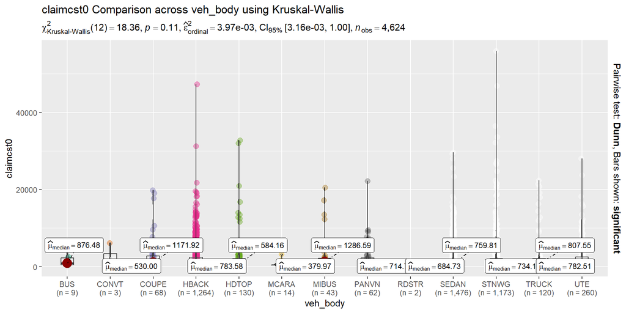

#### *B.3 kruskal.test on claims against age category*

- *B.3.1 kruskal.test on claims against age category as it has more than 2 factors*

```
##
##  Kruskal-Wallis rank sum test
##
## data:  df$claimcst0 and df$agecat
## Kruskal-Wallis chi-squared = 11.099, df = 5, p-value = 0.04946
```

*After Applying the test we found that:*

*The pvalue is less than 0.05 –> statistically there is significant difference in the data distribution between agecat*

- *B.3.2 Visualization*

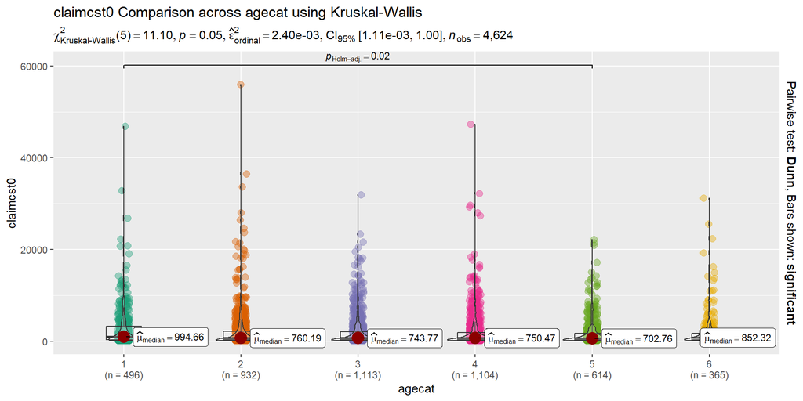

- *B.3.3 kruskal_effsize :*
- *now we want to assess and report the effect size and the magnitude of differences between these groups*

| .y. | n | effsize | method | magnitude |
| --- | --- | --- | --- | --- |
| claimcst0 | 4624 | 0.0013206 | eta2[H] | small |

- *The kruskal_effsize test showed that the effect size (epsilon_squared)= 0.001320641 and the indicating small effect size*
- *B.3.4 to find out in details these differences we will Perform Dunn’s Test with holm correction for p-values :*

```
##    Comparison           Z     P.unadj      P.adj
## 1       1 - 2  2.25523606 0.024118516 0.28942219
## 2       1 - 3  2.50162552 0.012362461 0.16071199
## 3       2 - 3  0.21869627 0.826886659 1.00000000
## 4       1 - 4  2.74351582 0.006078512 0.08509917
## 5       2 - 4  0.51604229 0.605824873 1.00000000
## 6       3 - 4  0.31181652 0.755179965 1.00000000
## 7       1 - 5  3.16592394 0.001545912 0.02318868
## 8       2 - 5  1.26571867 0.205613823 1.00000000
## 9       3 - 5  1.11552540 0.264625342 1.00000000
## 10      4 - 5  0.85082071 0.394868957 1.00000000
## 11      1 - 6  1.94645859 0.051599677 0.56759645
## 12      2 - 6  0.14394179 0.885546439 1.00000000
## 13      3 - 6 -0.01363333 0.989122512 0.98912251
## 14      4 - 6 -0.23298594 0.815772326 1.00000000
## 15      5 - 6 -0.86090528 0.389290214 1.00000000
```

*From the above table we can get that :*

- *The p.adjusted value is less than 0.05 only between agecat 1-5 –> statistically there is significant difference in the data distribution between these groups,and there is no statistically significant difference in the data distribution between all other agecat groups*
- *B.3.5 Assumption Checks:*
- *Check the homogeneity of variances using Levene’s test.*

```r
levene_test <- leveneTest(claimcst0 ~agecat,data=df)
print(levene_test)
```

```
## Levene's Test for Homogeneity of Variance (center = median)
##         Df F value    Pr(>F)
## group    5  4.5834 0.0003578 ***
##       4618
## ---
## Signif. codes:  0 '***' 0.001 '**' 0.01 '*' 0.05 '.' 0.1 ' ' 1
```

- *The test indicates that the variances are significantly different across the groups (p-value < 0.05).*
- *B.3.6 Post-hoc Power Analysis:*
- *Conduct a post-hoc power analysis based on the effect size.*

```r
effect_size <- sqrt(eff_size$effsize)
power_analysis <- pwr.anova.test(k = length(unique(df$agecat)),
                                 n = nrow(df) / length(unique(df$agecat)),
                                 f = effect_size,
                                 sig.level = 0.05,
                                 power = NULL)
print(power_analysis)
```

```
##
##      Balanced one-way analysis of variance power calculation
##
##               k = 6
##               n = 770.6667
##               f = 0.03634062
##       sig.level = 0.05
##           power = 0.4397375
##
## NOTE: n is number in each group
```

- *The power of the test is 0.4397375,This means there is a 43.9% chance of detecting a true effect.*

#### *B.4 kruskal.test on claims against number of claims*

- *B.4.1 kruskal.test on claims against number of claims as it has more than 2 factors*

```
##
##  Kruskal-Wallis rank sum test
##
## data:  df$claimcst0 and df$numclaims
## Kruskal-Wallis chi-squared = 159.02, df = 3, p-value < 2.2e-16
```

*After Applying the test we found that:*

*The pvalue is less than 0.05 –> statistically there is significant difference in the data distribution between numclaims*

- *B.4.2 Visualization*

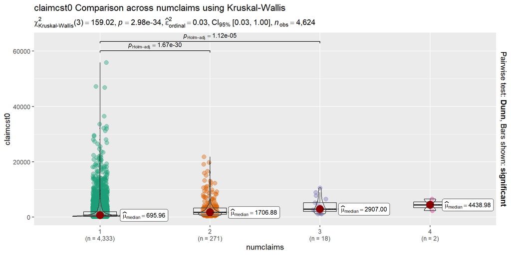

- *B.4.3 kruskal_effsize :*
- *now we want to assess and report the effect size and the magnitude of differences between these groups*

| .y. | n | effsize | method | magnitude |
| --- | --- | --- | --- | --- |
| claimcst0 | 4624 | 0.0337713 | eta2[H] | small |

- *The kruskal_effsize test showed that the effect size (epsilon_squared)= 0.0337713 and the indicating small effect size*
- *B.4.4 to find out in details these differences we will Perform Dunn’s Test with holm correction for p-values :*

```
##   Comparison           Z      P.unadj        P.adj
## 1      1 - 2 -11.6335467 2.782897e-31 1.669738e-30
## 2      1 - 3  -4.7312845 2.231036e-06 1.115518e-05
## 3      2 - 3  -1.5983152 1.099729e-01 3.299186e-01
## 4      1 - 4  -1.7924333 7.306358e-02 2.922543e-01
## 5      2 - 4  -0.7598618 4.473372e-01 8.946744e-01
## 6      3 - 4  -0.2015760 8.402482e-01 8.402482e-01
```

*From the above table we can get that :*

- *The p.adjusted value is less than 0.05 between numclaims 1-2 ,numclaims 1-3 –> statistically there is significant difference in the data distribution between these groups,and there is no statistically significant differences in the data distribution between all other numclaims groups*
- *B.4.5 Assumption Checks:*
- *Check the homogeneity of variances using Levene’s test.*

```r
levene_test <- leveneTest(claimcst0 ~numclaims,data=df)
print(levene_test)
```

```
## Levene's Test for Homogeneity of Variance (center = median)
##         Df F value Pr(>F)
## group    3  0.9987 0.3923
##       4620
```

- *The test indicates that the variances are not significantly different across the groups (p-value > 0.05).*
- *B.4.6 Post-hoc Power Analysis:*
- *Conduct a post-hoc power analysis based on the effect size.*

```r
effect_size <- sqrt(eff_size$effsize)
power_analysis <- pwr.anova.test(k = length(unique(df$numclaims)),
                                 n = nrow(df) / length(unique(df$numclaims)),
                                 f = effect_size,
                                 sig.level = 0.05,
                                 power = NULL)
print(power_analysis)
```

```
##
##      Balanced one-way analysis of variance power calculation
##
##               k = 4
##               n = 1156
##               f = 0.1837697
##       sig.level = 0.05
##           power = 1
##
## NOTE: n is number in each group
```

- *The power of the test is 1,This means there is a 100% chance of detecting a true effect.*

#### *B.5 kruskal.test on claims against veh_age*

- *B.5.1 kruskal.test on claims against veh_age as it has more than 2 factors*

```
##
##  Kruskal-Wallis rank sum test
##
## data:  df$claimcst0 and df$veh_age
## Kruskal-Wallis chi-squared = 18.668, df = 3, p-value = 0.0003201
```

*After Applying the test we found that:*

*The pvalue is less than 0.05 –> statistically there is significant difference in the data distribution between veh_age*

- *B.5.2 Visualization*

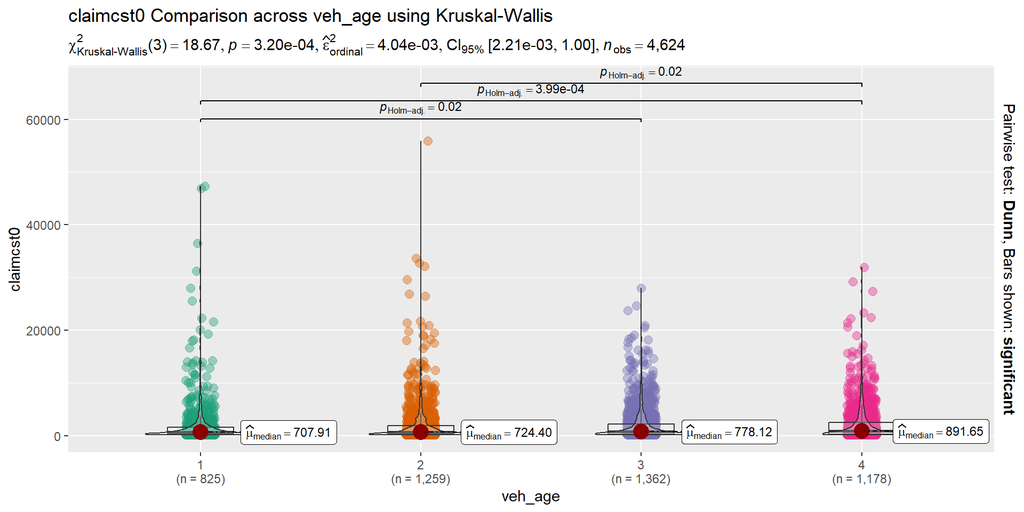

- *B.5.3 kruskal_effsize :*
- *now we want to assess and report the effect size and the magnitude of differences between these groups*

| .y. | n | effsize | method | magnitude |
| --- | --- | --- | --- | --- |
| claimcst0 | 4624 | 0.0033914 | eta2[H] | small |

- *The kruskal_effsize test showed that the effect size (epsilon_squared)= 0.003391443 and the indicating small effect size*
- *B.5.4 to find out in details these differences we will Perform Dunn’s Test with holm correction for p-values :*

```
##   Comparison         Z      P.unadj        P.adj
## 1      1 - 2 -1.401384 1.610994e-01 0.3221987936
## 2      1 - 3 -2.860319 4.232150e-03 0.0169286002
## 3      2 - 3 -1.622098 1.047823e-01 0.3143468597
## 4      1 - 4 -3.988218 6.657135e-05 0.0003994281
## 5      2 - 4 -2.918060 3.522165e-03 0.0176108256
## 6      3 - 4 -1.379031 1.678852e-01 0.1678852290
```

*From the above table we can get that :*

- *The p.adjusted value is less than 0.05 only between veh_age 1-3 ,veh_age 1-4 ,veh_age 2-4 –> statistically there is significant difference in the data distribution between these groups,and there is no statistically significant difference in the data distribution between all other veh_age groups*
- *B.5.5 Assumption Checks:*
- *Check the homogeneity of variances using Levene’s test.*

```r
levene_test <- leveneTest(claimcst0 ~veh_age,data=df)
print(levene_test)
```

```
## Levene's Test for Homogeneity of Variance (center = median)
##         Df F value Pr(>F)
## group    3   0.926 0.4272
##       4620
```

- *The test indicates that the variances are not significantly different across the groups (p-value > 0.05).*
- *B.5.6 Post-hoc Power Analysis:*
- *Conduct a post-hoc power analysis based on the effect size.*

```r
effect_size <- sqrt(eff_size$effsize)
power_analysis <- pwr.anova.test(k = length(unique(df$veh_age)),
                                 n = nrow(df) / length(unique(df$veh_age)),
                                 f = effect_size,
                                 sig.level = 0.05,
                                 power = NULL)
print(power_analysis)
```

```
##
##      Balanced one-way analysis of variance power calculation
##
##               k = 4
##               n = 1156
##               f = 0.0582361
##       sig.level = 0.05
##           power = 0.9288195
##
## NOTE: n is number in each group
```

- *The power of the test is 0.92,This means there is a 92% chance of detecting a true effect.*

**————————————————————————**

# *Insurance risk measurements by factors.*

- *as the insurance risk level is measured by the frequency and the severity; we will calculate the the same and group it by factors.*

## *gender factor*

| gender | claimcst0 | numclaims | exposure | frequency | average_severity | risk_premium |
| --- | --- | --- | --- | --- | --- | --- |
| F | 4908749 | 2832 | 17954.60 | 0.1577311 | 1733.315 | 273.3978 |
| M | 4405855 | 2105 | 13846.21 | 0.1520271 | 2093.043 | 318.1993 |

> *we can see that :*
- *females number of claims are more than males.*
- *females claims cost are more than males but; the average severity is less ,and this is due to the larger number of claims(more than males)*
- *both females and males almost have the same frequency.*
- *female risk premium is lesser than males ,and this due to the higher exposure females have.*

*the below chart visualize all together for more clear understanding:*

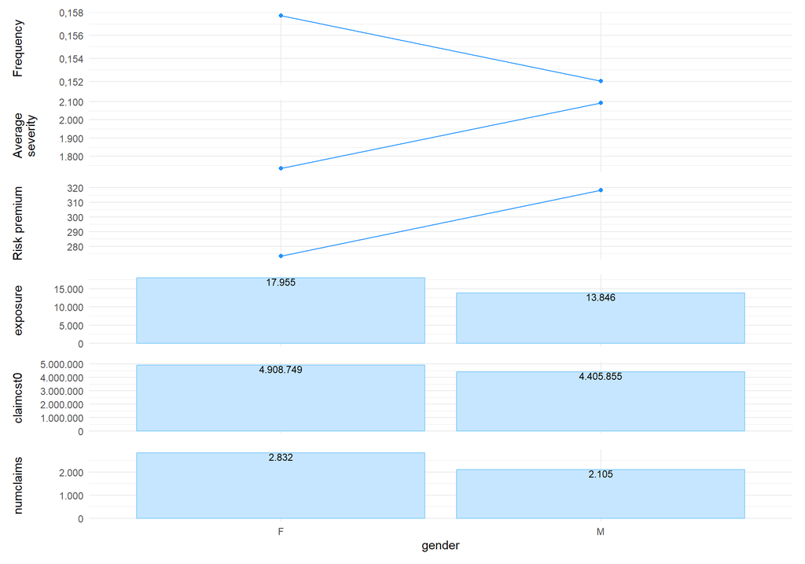

## *veh_age factor*

| veh_age | claimcst0 | numclaims | exposure | frequency | average_severity | risk_premium |
| --- | --- | --- | --- | --- | --- | --- |
| 3 | 2718237 | 1446 | 9542.111 | 0.1515388 | 1879.832 | 284.8675 |
| 2 | 2486217 | 1354 | 7923.677 | 0.1708803 | 1836.202 | 313.7706 |
| 4 | 2554895 | 1261 | 8996.079 | 0.1401722 | 2026.087 | 284.0010 |
| 1 | 1555255 | 876 | 5338.951 | 0.1640772 | 1775.405 | 291.3034 |

> *we can see that :*
- *the claims cost for the vehicle age 1 is the lowest while for vehicle age 3 is the highest.*
- *vehicle age 1 has the lowest number on claims while the vehicle age 3 has the highest.*
- *the exposure for the vehicle age 1 is the lowest while for vehicle age 3 is the highest.*
- *the frequency for the vehicle age 4 is the lowest while for vehicle age 2 is the highest.*
- *the average_severity for the vehicle age 1 is the lowest while for vehicle age 4 is the highest.*
- *the risk premium for the vehicle age 3 & 4 is the lowest and almost the same, while its the highest for vehicle age 2*

*the below chart visualize all together for more clear understating :*

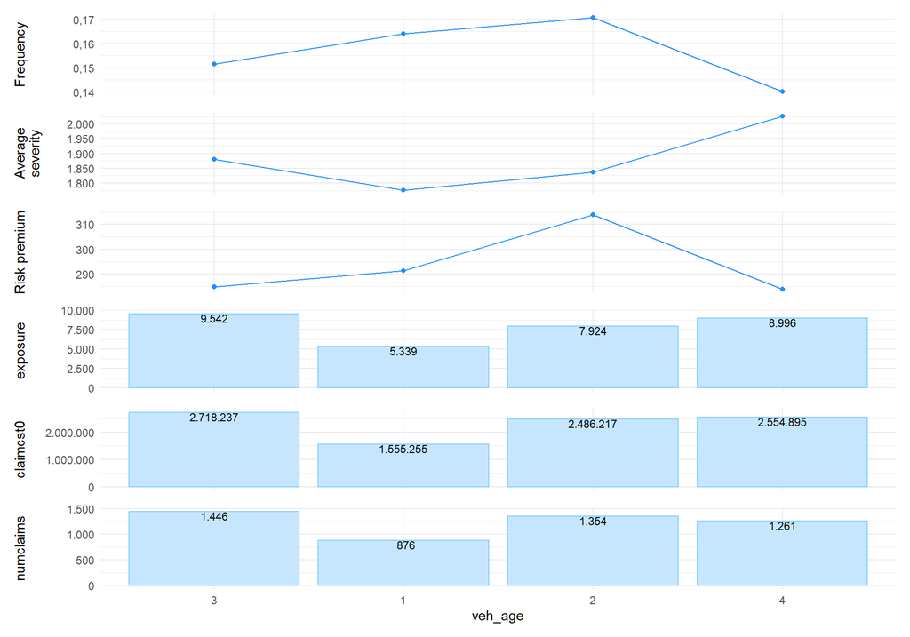

## *veh_body factor*

| veh_body | claimcst0 | numclaims | exposure | frequency | average_severity | risk_premium |
| --- | --- | --- | --- | --- | --- | --- |
| HBACK | 2589136.192 | 1330 | 8810.31348 | 0.1509594 | 1946.7189 | 293.8756 |
| UTE | 597208.965 | 276 | 2105.73032 | 0.1310709 | 2163.8006 | 283.6113 |
| STNWG | 2363091.211 | 1248 | 7638.39014 | 0.1633852 | 1893.5026 | 309.3703 |
| HDTOP | 294811.869 | 136 | 783.29911 | 0.1736246 | 2167.7343 | 376.3720 |
| PANVN | 133113.412 | 68 | 409.16085 | 0.1661938 | 1957.5502 | 325.3327 |
| SEDAN | 2681622.477 | 1598 | 10444.59959 | 0.1529977 | 1678.1117 | 256.7473 |
| TRUCK | 319496.849 | 130 | 843.96441 | 0.1540349 | 2457.6681 | 378.5667 |
| COUPE | 187723.251 | 75 | 319.12663 | 0.2350164 | 2502.9767 | 588.2406 |
| MIBUS | 116104.880 | 45 | 316.84052 | 0.1420273 | 2580.1084 | 366.4458 |
| MCARA | 10673.950 | 15 | 59.27995 | 0.2530367 | 711.5967 | 180.0601 |
| BUS | 13363.120 | 10 | 25.84805 | 0.3868764 | 1336.3120 | 516.9876 |
| CONVT | 6888.810 | 3 | 32.59685 | 0.0920334 | 2296.2700 | 211.3336 |
| RDSTR | 1369.458 | 3 | 11.66872 | 0.2570976 | 456.4861 | 117.3615 |

*the below chart visualize all together for more clear understanding:*

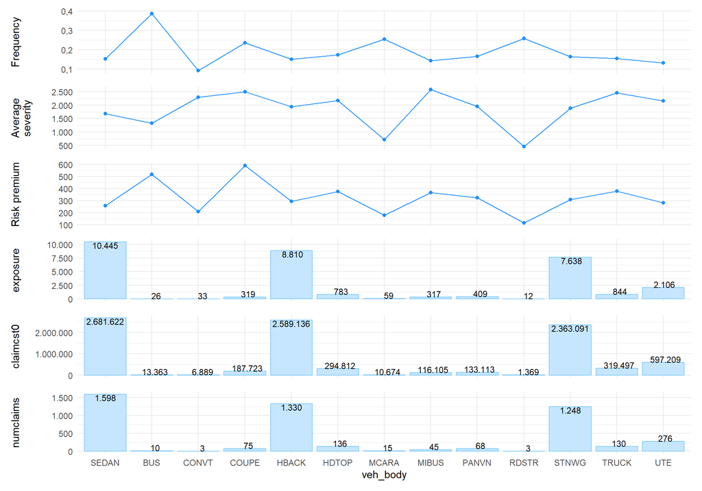

## *area factor*

| area | claimcst0 | numclaims | exposure | frequency | average_severity | risk_premium |
| --- | --- | --- | --- | --- | --- | --- |
| C | 2865707.2 | 1493 | 9578.494 | 0.1558700 | 1919.429 | 299.1814 |
| A | 2071765.6 | 1181 | 7597.101 | 0.1554540 | 1754.247 | 272.7048 |
| E | 868822.9 | 413 | 2771.866 | 0.1489971 | 2103.687 | 313.4434 |
| D | 911058.2 | 524 | 3819.518 | 0.1371901 | 1738.661 | 238.5270 |
| B | 1795295.2 | 1021 | 6297.848 | 0.1621189 | 1758.369 | 285.0649 |
| F | 801955.4 | 305 | 1735.992 | 0.1756921 | 2629.362 | 461.9581 |

> *we can see that :*
- *the lowest claims cost is for area F , and the highest cost is for area C.*
- *area F has the lowest number of claims , while area C has the highest .*
- *area D has the lowest frequency , while area F has the highest.*
- *area D has the lowest average frequency ,while area F has the highest.*
- *area D has the lowest risk premium , while area F has the highest.*

*the below chart visualize all together for more clear understanding:*

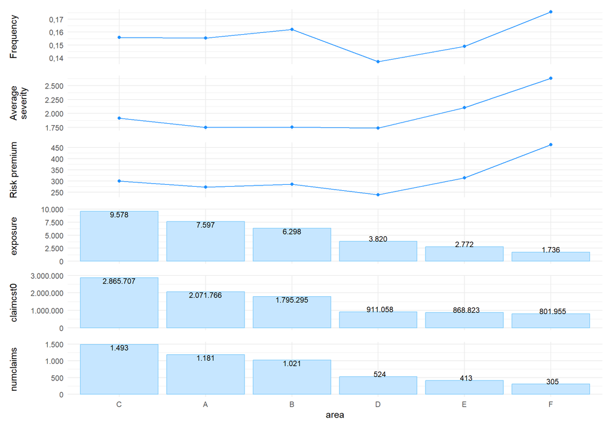

## *age category factor*

| agecat | claimcst0 | numclaims | exposure | frequency | average_severity | risk_premium |
| --- | --- | --- | --- | --- | --- | --- |
| 2 | 1984840.8 | 1000 | 5891.871 | 0.1697254 | 1984.841 | 336.8778 |
| 4 | 2145303.0 | 1185 | 7616.542 | 0.1555824 | 1810.382 | 281.6636 |
| 6 | 683568.5 | 390 | 3099.666 | 0.1258200 | 1752.740 | 220.5297 |
| 3 | 2132107.1 | 1189 | 7409.457 | 0.1604706 | 1793.194 | 287.7549 |
| 5 | 1061412.2 | 648 | 5171.009 | 0.1253140 | 1637.982 | 205.2621 |
| 1 | 1307372.9 | 525 | 2612.274 | 0.2009743 | 2490.234 | 500.4732 |

> *we can see that :*
- *age category 6 has the lowest claims cost , while age category 4 has the highest*
- *age category 6 has the lowest number of claims , while age category 4 & 3 has the highest (1185,1189) .*
- *age category 6 & 5 has the lowest frequency with almost(12.5%) , while age category 1 has the highest with 20%.*
- *age category 5 has the lowest average frequency ,while age category 1 has the highest.*
- *age category 5 has the lowest risk premium , while age category 1 has the highest.*

*the below chart visualize all together for more clear understanding:*

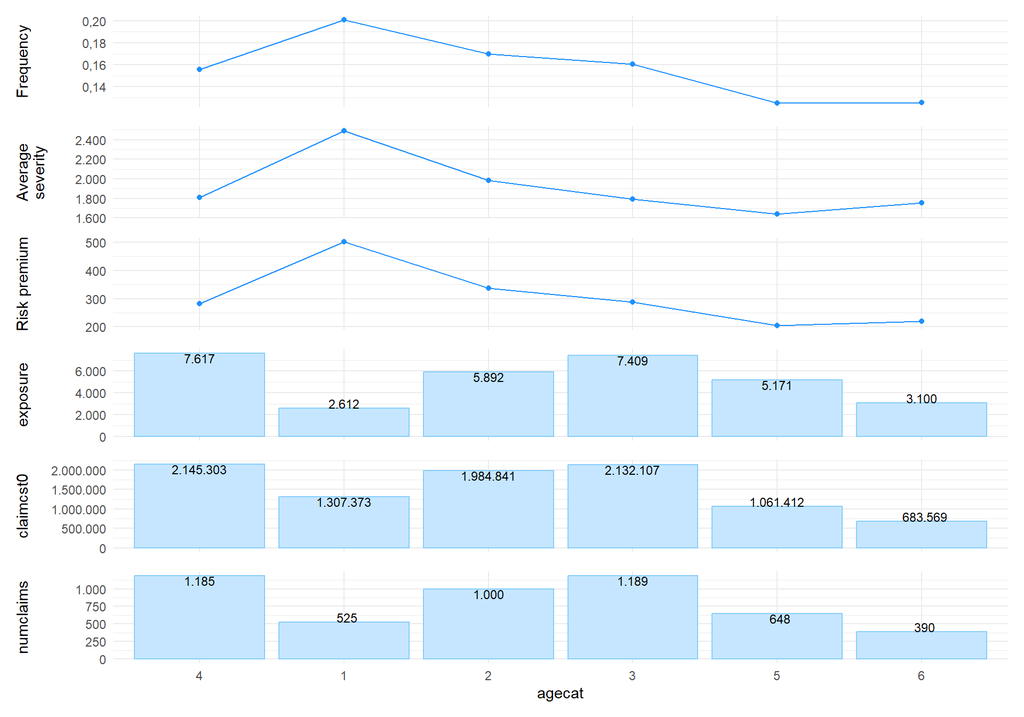